# LIQUIDEZ MONETARIA Y TASA DE INTERÉS COMO MECANISMOS DE TRANSMISIÓN HACIA EL CRECIMIENTO ECONÓMICO EN EL ECUADOR DOLARIZADO: UN ANÁLISIS DE CORTO Y LARGO PLAZO (2000–2025) **ECONOMÍA EN LÍNEA** **UNIVERSIDAD ESTATAL DE MILAGRO (UNEMI)**

Kenzi Saul Motomura Tumaylle

Daniel Alexander Pareja Veliz

03 de julio de 2026

# **Resumen**

# **Introducción**

La relación entre la liquidez y el crecimiento económico ha sido ampliamente estudiada en la literatura económica debido a su importancia para la estabilidad macroeconómica y el desarrollo de los países. Desde la perspectiva monetaria, la disponibilidad de recursos financieros dentro de una economía influye sobre las decisiones de consumo, ahorro e inversión, afectando directamente la dinámica productiva y el crecimiento económico; diversos estudios han señalado que las condiciones monetarias constituyen un factor relevante para explicar las fluctuaciones de la producción y el desempeño económico de largo plazo. (Sultana, 2018; León & Gonzáles, 2022)

Las restricciones monetarias asociadas a la dolarización se hicieron evidentes desde el propio proceso de transición. Durante la adopción del dólar como moneda oficial, el Banco Central del Ecuador (BCE) dejó de ejecutar un amplio proceso de canje monetario, mediante el cual se retiraron de circulación aproximadamente 14,2 billones de sucres y se inyectaron alrededor de 567,5 millones dólares para abastecer la demanda que surgió en la economía. Como consecuencia, la disponibilidad de liquidez pasó a depender fundamentalmente de factores externos como las exportaciones, las remesas, la inversión extranjera y el ingreso de divisas (Meireles & Rivera, 2023).

Así lo afirma Paredes & Freire (2024), en su investigación quienes señalan que la ausencia de una moneda propia restringe los mecanismos de ajuste macroeconómico disponibles para Ecuador, lo que ha favorecido una creciente dependencia del financiamiento mediante deuda pública frente a choques externos y restricciones de liquidez. Analizando los datos del BCE, podemos ver que del 2012 al 2014 la economía se benefició al principio por un contexto internacional, por altos precios históricos del petróleo los cuales pasaron de entre 98-100 dólares en el 2012-2013 a bajar a los 84 dólares en el 2014 y siguió disminuyendo en el 2015, lo cual si bien provocó un incremento en los ingresos del sector exportador y por tanto ingreso de divisas y crecimiento económico, también evidenció la vulnerabilidad ante choques externos y la dependencia de ingresos del sector exportador ya que en el segundo trimestre del 2015 luego de la caída del precio del petróleo, el PIB pasó de haber crecido un 4.0% a tan solo un 2.0% (BCE, 2016)

Teniendo como base investigativa, el trabajo de Sultana (2018), quien realizó un estudio ARDL donde analizó los efectos de la oferta monetaria, la tasa de inflación y la tasa de interés en el crecimiento económico de Bangladesh; los resultados mostraron que en el largo plazo estas variables influyen positivamente en el crecimiento económico, mientras que la tasa de interés lo afecta de manera negativa; en el corto plazo no se encontraron relaciones significativas entre las variables. Según nos expresan León & González (2022), que en su trabajo encontraron que las condiciones monetarias internacionales tienen efectos sobre el crecimiento económico de las economías dolarizadas. Estos resultados nos demuestran que en ausencia de una política monetaria autónoma, las variables financieras y monetarias adquieren un papel mucho más protagónico como mecanismos de transmisión macroeconómica.

## **Justificación**

La presente investigación se justifica por la necesidad de comprender los factores que determinan el crecimiento económico en una economía dolarizada. Debido a las limitaciones que enfrenta Ecuador para aplicar instrumentos tradicionales de política monetaria, resulta relevante analizar el comportamiento de variables como la liquidez M2, la tasa de interés, las exportaciones y la inflación, las cuales pueden influir sobre la actividad económica a través de distintos mecanismos de transmisión.

Además, existe una limitada evidencia empírica para el caso ecuatoriano que analice simultáneamente la relación entre liquidez, tasa de interés y crecimiento económico bajo un enfoque de corto y largo plazo. Por ello, esta investigación busca aportar evidencia que contribuya a la formulación de políticas públicas orientadas a fortalecer la estabilidad financiera y el crecimiento sostenible del país.

# **Objetivos de investigación**

## **Objetivo general**

Analizar la influencia de la liquidez M2 sobre el crecimiento económico del Ecuador y evaluar el papel de la tasa de interés como canal de transmisión en una economía dolarizada.

## **Objetivos específicos**

· Determinar la relación de largo plazo entre la liquidez M2 y el PIB real en Ecuador

· Analizar el efecto de la tasa de interés sobre el crecimiento económico.

· Evaluar las incidencias de las exportaciones y la inflación sobre el PIB real.

· Examinar las dinámicas de corto y largo plazo entre las variables mediante un modelo ARDL-ECM.

## **Pregunta de investigación**

Bajo este contexto, surge la necesidad de analizar la relación entre liquidez M2, la tasa de interés, valor total de las exportaciones, la tasa de inflación y el PIB real; donde se buscaría responder: *¿En qué medida la liquidez M2 influye en el crecimiento económico en el Ecuador y cuál es el rol de la tasa de interés como canal de transmisión en una economía dolarizada?* el cual tiene relevancia al mostrar la disponibilidad de dinero dentro del sistema financiero y por lo tanto, la tasa de interés se configura como un canal fundamental para el sector financiero y la economía real afectando a la toma de decisiones en inversión y consumo.

## **Metodologia de la investigación**

Para alcanzar los objetivos planteados se empleará un modelo Autorregresivo de Rezagos Distribuidos (ARDL-ECM), el cual permitirá analizar las relaciones de corto y largo plazo entre la liquidez M2, la tasa de interés, las exportaciones, la inflación y el PIB real. Asimismo, se aplicará pruebas de raíz unitaria mediante el test de Dickey Fuller aumentado (ADF), con el propósito de verificar las propiedades estadísticas de las series temporales y garantizar la validez de las estimaciones econométricas.

El aporte principal de este estudio radica en examinar la liquidez como un mecanismo alternativo de transmisión económica dentro de un régimen de dolarización, contribuyendo a la compresión de los determinantes del crecimiento económico ecuatoriano y generando evidencia útil para el diseño de políticas públicas orientadas a fortalecer la estabilidad macroeconómica y financiera.

# **Revision de la litteratura**

## **Fundamentación teorica y conceptualización de variables.**

### **Política Monetaria**

La política monetaria constituye uno de los principales instrumentos de estabilización macroeconómica, al permitir a los bancos centrales influir sobre las variables como la inflación, la tasa de interés y el crecimiento económico. Este se entiende como el conjunto de acciones orientadas a controlar la oferta monetaria con el objetivo de incidir en la dinámica económica de un país (Cuadrado-Roura et al., 2010). De manera complementaria Checo et al. (2024), señalan que la política monetaria afecta a la actividad económica a través de distintos mecanismos de transmisión que inciden sobre el crédito, el consumo y la inversión de los agentes financieros.

Podemos decir que la política monetaria es un pilar fundamental del crecimiento económico y en economías dolarizadas como la de Ecuador donde las herramientas convencionales son limitadas, resulta pertinente analizar variables relacionadas con la liquidez y las condiciones financieras como mecanismos alternativos de transmisión económica.

### **Producto interno bruto real (PIB REAL)**

El PIB mide el gasto total de bienes y servicios en todos los mercados en la economía, si el gasto total aumenta de un año al siguiente, al menos una de estas dos cosas debe ser cierta: 1) la economía está produciendo una mayor cantidad de bienes y servicios, o 2) los bienes y servicios se están vendiendo a precios más altos. Cuando se estudian los cambios en la economía a lo largo del tiempo, los economistas normalmente quieren separar estos dos efectos. En particular, quieren medir la cantidad total de bienes y servicios que está produciendo la economía y que no se ve afectada por los cambios en los precios de esos bienes y servicios. Para hacer esto, los economistas utilizan esta medida llamada PIB real. (Mankiw, 2012, p. 499)

Según Pulgar et al. (2024), con base metodológica de las cuentas nacionales del Banco Central del Ecuador, el Producto Interno Bruto (PIB) real se define como el valor monetario de los bienes y servicios finales producidos dentro de una economía durante un periodo determinado, medido a precios constantes para eliminar el efecto de la inflación. De igual manera Reyes et al. (2024) sostiene que el PIB real constituye uno de los principales indicadores para evaluar el crecimiento económico, ya que permite analizar las variaciones efectivas en la producción nacional sin las distorsiones generadas por los cambios en los niveles de precios.

### **Tasa de interés en la economía**

Según el Banco Central del Ecuador (2022), define a la tasa de interés como un valor que es determinado por un monto monetario en un periodo de tiempo, incluso conceptualiza la tasa de interés como el precio del dinero en el tiempo. En el trabajo de Vargas & Muñoz (2020) nos mencionan que en economías industrializadas, la tasa de interés fijada por los entes bancarios centrales son dadas en el mercado y se la usa como herramienta de política monetaria, las tasas que son a corto plazo inciden en operaciones menores a un año y que las de largo plazo pasan a función de la economía real.

El BCE (2025), también nos define específicamente la Tasa de Interés Activa como el porcentaje que una institución financiera cobra sobre los préstamos o créditos otorgados a sus clientes, reflejando el costo del dinero prestado y determinando el rendimiento que la entidad recibe por sus operaciones de crédito.

Es por esto por lo que la tasa de interés activa nominal se incorpora como variable explicativa debido a que constituye uno de los principales mecanismos de transmisión entre la liquidez y el crecimiento económico. En una economía dolarizada como la ecuatoriana, donde la política monetaria es limitada, las variaciones en la liquidez del sistema financiero pueden influir sobre el costo del crédito y de esta manera afecta las decisiones de inversión y consumo del sector privado.

### **Liquidez M2 (Oferta Monetaria)**

Pérez & Guncay (2019) analizan la oferta monetaria desde la perspectiva de la endogeneidad del dinero en economías dolarizadas, donde mencionan que la liquidez M2 es una variable pilar para entender la dinámica monetaria, según los autores la oferta monetaria se puede comprender como un agregado que denota la liquidez total de la economía, compuesto como el dinero en efectivo en circulación, depósitos a la vista y otros deposito altamente líquidos dentro del sistema bancario; además sostienen que la oferta monetaria en Ecuador no es completamente exógena, sino que depende del crédito bancario y del comportamiento del sistema financiero, lo que refleja la teoría de que M2 es una variable endógena al sistema económico. Así mismo Zuluaga & Checa (2023), definen a la oferta monetaria M2 como un indicador fundamental para analizar la estabilidad del sistema monetario y su relación con la economía real. En su estudio sobre Ecuador explican que M2 representa la liquidez ampliada de la economía, no solo incorporando el efectivo sino también depósitos a la vista y depósitos de ahorro, esto permite medir la capacidad de gasto y financiamiento del sistema económico, destacan que M2 es crucial para analizar el equilibrio entre la oferta y demanda monetaria, ya que su comportamiento refleja la interacción entre el sistema financiero, el crédito y la actividad económica, especialmente en economías con fuerte influencia del sistema bancario.

### **Exportaciones**

Según Ponce et al. (2025), en su trabajo considera que las exportaciones constituyen la venta de bienes y servicios producidos en un país hacia mercados internacionales, generando ingresos de divisas y contribuyendo al crecimiento económico; los autores hacen énfasis en que las exportaciones representan uno de los principales mecanismos de integración de una economía al comercio mundial, permitiendo incrementar la producción, el empleo y la competitividad social.

En otro trabajo realizado por Paredes & Donoso (2022), analizan las exportaciones como el conjunto de bienes producidos por una economía que son comercializados en el exterior. Los autores enfatizan que las exportaciones permiten diversificar la estructura productiva, ampliar los mercados para los productos nacionales y fortalecer la inserción internacional del país; incluso mencionan que la composición de las exportaciones refleja el grado de desarrollo y competitividad de una economía.

### **Inflación**

Según Intriago (2022), en su trabajo define la inflación como un fenómeno económico caracterizado por el aumento sostenido y generalizado de los precios de bienes y servicios en una economía durante un periodo determinado, lo que provoca una disminución del poder adquisitivo del dinero; el autor destaca que, cuando los precios suben de manera continua, una misma cantidad de dinero permite adquirir menos bienes y servicio que anteriormente. Así lo confirma Mejia et al. (2023), quienes abordan la inflación como una variable macroeconómica fundamental que refleja el comportamiento general de los precios y que influye directamente sobre el crecimiento económico, las decisiones de inversión y la política monetaria; estos señalan que la inflación representa la variación persistente del nivel general de precios en una economía y constituye uno de los principales indicadores de estabilidad macroeconómica.

## **Antecedentes teóricos**

Para poder ser pragmáticos el poder analizar qué nos dicen las escuelas clásicas de la economía, nos ayuda a entender la relación entre las variables que se usarán en nuestra investigación, justificando de manera histórica la relación entre estas.

### **Enfoque Clásico**

Desde la perspectiva clásica, el crecimiento económico depende principalmente de la acumulación de capital y expansión de la actividad productiva; en este contexto, la disponibilidad de recursos financieros facilita la inversión y la formación de capital, elementos fundamentales para el crecimiento de largo plazo.

Entre los autores más relevantes de la escuela clásica se encuentra Adam Smith quien sostiene que el crecimiento económico surge de la especialización productiva, la división del trabajo y la expansión de los mercados; argumentaba que el comercio y la acumulación de capital permiten aumentar la productividad y la riqueza de las naciones; en una revisión contemporánea Loannou & Wójick (2022) destacan que los planteamientos de Smith continúan siendo relevantes para explicar el desarrollo económico, particularmente a través de la integración de los mercados, el comercio y las instituciones que favorecen la productividad.

### **Enfoque Keynesiano**

Desde la perspectiva keynesiana, la liquidez y la tasa de interés desempeñan un papel central en la determinación de la inversión y del nivel de actividad económica; un incremento de la oferta monetaria puede reducir la tasa de interés, favoreciendo el acceso al crédito y estimulando la inversión privada, lo que finalmente repercute en el crecimiento económico. Gali (2021), señala que los mecanismos monetarios continúan siendo determinantes para explicar las fluctuaciones macroeconómicas y la dinámica del producto especialmente a través de los efectos que las tasas de interés generan sobre las decisiones de consumo e inversión.

### **Enfoque monetarista**

La teoría monetarista sostiene que la cantidad de dinero desempeña un papel fundamental en la determinación de la actividad económica y del nivel general de precios. Las variaciones en la oferta monetaria afectan las decisiones de consumo, ahorro e inversión, generando efectos sobre el crecimiento económico en el corto y largo plazo. Asimismo, se argumenta que una expansión excesiva de la liquidez puede traducirse en presiones inflacionarias, por lo que el control de los agregados monetarios constituye un elemento esencial para la estabilidad macroeconómica. En una revisión reciente del pensamiento monetarista, Sumner (2022) destaca que muchos de los postulados desarrollados por Friedman continúan vigentes en el análisis macroeconómico moderno, especialmente aquellos relacionados con la influencia de la oferta monetaria sobre el producto y la inflación. Por esta razón es que la liquidez medida a través de M2 constituye una variable relevante para comprender el comportamiento del crecimiento económico y la estabilidad de precios.

### **Revisión académica**

La relación entre las variables monetarias y el crecimiento económico ha sido ampliamente estudiada en la literatura económica, encontrándose evidencia que respalda la importancia de la liquidez y la tasa de interés como mecanismo de transmisión macroeconómica; en este contexto, Abdulkadr et al. (2024) analizaron el impacto de la política monetaria sobre el crecimiento económico en Etiopía durante el periodo 1993-2022 mediante un modelo ARDL y un modelo ECM, estos utilizaron como variables explicativas la oferta monetaria, la tasa de interés y la inflación, encontrando una relación en el largo plazo entre dichas variables y el crecimiento económico. Sus resultados evidenciaron que la oferta monetaria presenta un efecto positivo y estadísticamente significativo sobre el PIB real, mientras que la tasa de interés mantiene una relación negativa debido a su impacto sobre la inversión y el financiamiento de las actividades productivas; en su trabajo mencionan que estas variables causan efectos en la política monetaria más relevante en el largo plazo que en el corto.

Así mismo de manera complementaria Bui & Gábor (2021), estudiaron el papel de la oferta monetaria y la tasa de interés como indicadores de política monetaria en doce economías emergentes que operaron bajo esquemas de metas de inflación. Mediante pruebas de causalidad de Granger, funciones impulso-respuesta y descomposición de varianza, los autores encontraron que tanto la oferta monetaria como la tasa de interés contiene información relevante para explicar la dinámica macroeconómica. No obstante, ellos concluyen que la oferta monetaria continúa siendo una variable fundamental para comprender los efectos de la política monetaria, debido a que captura información que no siempre es reflejada por la tasa de interés; los resultados muestran que el agregado monetario M2 mantiene un influencia consistente sobre variables macroeconómicas clave, mientras que la respuesta de la inflación y de otras variables macroeconómicas ante cambios en la tasa de interés pueden variar según características estructurales de cada economía. Uno de los estudios más cercanos a la presente investigación es realizado por Sultana (2018), quien analizó los efectos de la oferta monetaria, la tasa de inflación, interés sobre el crecimiento económico de Bangladesh durante el periodo de 1981-2016; para ello empleó un modelo ARDL y lo complemento con un modelo ECM, con ello su objetivo fue identificar las relaciones al corto y largo plazo entre las variables. Sus resultados arrojaron que existe una relación de equilibrio en el largo plazo entre la oferta monetaria y las demás variables, con números significativos estadísticamente sobre el crecimiento económico; al igual que la teoría nos muestra Sultana estadísticamente que la tasa de interés tiene un efecto negativo sobre la inversión, destacó la relación a largo plazo entre las variables y que la liquidez es un factor primordial como impulsor de la actividad económica.

# **Materiales y métodos**

## **Diseño metodologico**

La presente investigación se desarrolló bajo un enfoque cuantitativo, debido a que analiza la relación existente entre la liquidez monetaria (M2), la tasa de interés, las exportaciones, la inflación y el crecimiento económico del Ecuador mediante la aplicación de técnicas econométricas de series de tiempo. Este enfoque permite medir objetivamente el comportamiento de las variables macroeconómicas, estimar la magnitud de sus relaciones y contrastar las hipótesis planteadas a partir de evidencia empírica.

El estudio posee un alcance explicativo, puesto que busca determinar como la liquidez M2 y la tasa de interés actúan como mecanismos de transmisión hacia el crecimiento económico dentro de una economía dolarizada. Asimismo, se pretende identificar tanto los efectos de corto plazo como las relaciones de equilibrio de largo plazo entre las variables consideradas, permitiendo comprender la dinámica macroeconómica del Ecuador durante el periodo analizado. Desde el punto de vista metodológico la investigación presenta un diseño no experimental. Longitudinal y series de tiempo, debido a que las variables objeto de estudio no son manipuladas, sino que se analizan a partir de información de data histórica observada entre los años 2000-2025. En base a esto se examina la evolución temporal de las variables económicas mediante observaciones anuales correspondientes a una misma económica, permitiendo evaluar los mecanismos de ajuste ante distintos escenarios macroeconómicos.

La información utilizada proviene de fuentes de acceso público, el Producto Interno Bruto real, la Liquidez M2, las exportaciones totales y la tasa de interés fueron obtenidos del Banco Central del Ecuador, mientas que la tasa de inflación anual fue extraída del Instituto Nacional de Estadísticas y Censos (INEC), la utilización de estadísticas oficiales garantiza la consistencia metodológica, confiabilidad y comparabilidad de las series empleadas en el análisis econométrico. Considerando las caract4eristicas de la muestra (26 observaciones anuales) y la naturaleza de las variables económicas, la investigación emplea el modelo Autorregresivo de Rezagos Distribuidos (ARDL) desarrollado por Pesaran, Shin y Smith (2021). Esta metodología resulta adecuada para miu8estras pequeñas y permite estimar relacione entre variables que presentan diferentes ordenes de integración, siempre que ninguna sea integrada de orden dos, 1(2); asimismo, posibilita estimar simultáneamente las relaciones de equilibrio de largo plazo y los ajustes dinámicos de corto plazo mediante un Modelo de Corrección del Error (ECM).

El procedimiento metodológico comprende de varias etapas, inicialmente se realiza una exploración descriptiva de la base de datos, verificando la calidad de la información y transformando mediante logaritmos naturales las variables expresadas en millones de dólares para reducir su dispersión y facilitar la interpretación de las elasticidades. Posteriormente, se evalúa la estacionariedad de las series mediante la prueba de raíz unitaria de Dickey Fuller Aumentada (ADF), con el propósito de identificar su orden de integración. Una vez comprobando que las variables cu7mplen los supuestos requeridos por la metodología ARDL, se determina el numero optimo de rezagos utilizando criterio de información estadística y se estima el modelo econométrico. Finalmente se aplica la prueba de limites (Bound test) para verificar la existencia de cointegración, se estima el Modelo de Corrección del Error (ECM) y se realizan pruebas de diagnostico y estabilidad para validar la robustez de los resultados obtenidos

## **Especificación del modelo econométrico**

Con base en el objetivo de la investigación, se plantea un modelo econométrico que tiene como variable dependiente el Producto Interno Bruto (PIB) real y como variables explicativas la liquidez monetaria (M2), la tasa de interés, las exportaciones y la inflación. La relación funcional propuesta es la siguiente: PIB=f(M2,INT,EXP,INF) Dado que el PIB real, la Liquidez monetaria y las exportaciones se encuentran expresadas en millones de dólares, estas variables fueron transformadas mediante logaritmo natural con el propósito de reducir la dispersión de los datos y facilitar la interpretación de los coeficientes como elasticidades. En contraste, la tasa de interés y la inflación permanecen expresadas en porcentaje, debido a que representan tasas y la inflación registra valores negativos durante algunos años del periodo de estudio.

$$\ln(\mathrm{PIB}_t)=\beta_0+\beta_1\ln(\mathrm{M2}_t)+\beta_2(\mathrm{INT}_t)+\beta_3\ln(\mathrm{EXP}_t)+\beta_4\mathrm{INF}_t+\varepsilon_t$$

Donde:

- PIB_t= Producto Interno Bruto real
- M2_t= Liquidez Monetaria
- INT_t= Tasa de Interés
- EXP_t= Exportaciones
- INF_t= Inflación
- ε_t= termino de error.

De acuerdo con la teoría económica, se espera que la liquidez monetaria y las exportaciones mantengan una relación positiva con el crecimiento económico, mientras que la tasa de interés presente un efecto negativo al incrementar el costo de financiamiento; en el caso de la inflación, el signo esperado es negativo debido a que aumentos persistentes del nivel de precios reducen el poder adquisitivo y generan incertidumbre sobre las decisiones de consumo e inversión.

## **Procedimiento econométrico.**

El procedimiento econométrico se desarrollo de forma secuencial. Inicialmente se efectuó la exploración y transformación de la base de datos; posterior se evaluó la estacionariedad de las series mediante la prueba de ADF, se selecciono la estructura optima de rezagos y se estimo un modelo ARDL.

Para finalizar se aplicó la prueba de limites Bound test para determinar la existencia de una relación de cointegración entre las variables. Una vez confirmada dicha relación, se estimo el Modelo ECM y se realizaron las pruebas de diagnóstico y estabilidad con el propósito de verificar el cumplimiento de los supuestos econométricos y garantizar la robustez de los resultados obtenidos.

# **Resultados y Limitaciones.**

## **Análisis descriptivos de las variables.**

Con el propósito de obtener una caracterización inicial de la información utilizada en el estudio, se realizó un análisis descriptivo de las variables correspondientes al periodo 2000-2025. Este procedimiento permitió identificar el comportamiento general de las series, verificar la existencia de valores atípicos y conocer su nivel de dispersión antes de aplicar las pruebas econométricas.

```r
library(knitr)
library(kableExtra)

tabla <- data.frame(
  Variable = c("lnPIB", "lnM2", "lnEXP", "Tasa de interés (%)", "Inflación (%)"),
  Observaciones = c(26, 26, 26, 26, 26),
  Media = c(11.35, 10.20, 9.83, 9.64, 7.13),
  `Desv. Est.` = c(0.26, 0.92, 0.60, 2.23, 17.70),
  Mínimo = c(10.86, 8.49, 8.65, 7.67, -0.90),
  Máximo = c(11.67, 11.52, 10.64, 15.53, 91.00)
)

kable(
  tabla,
  caption = "Tabla 1. Estadísticos descriptivos de las variables",
  align = "lccccc",
  booktabs = TRUE
) %>%
  kable_styling(
    full_width = FALSE,
    position = "center"
  ) %>%
  footnote(
    general = "Fuente: Elaboración propia con prueba de Rstudio datos del Banco Central del Ecuador (2025).",
    general_title = "Nota: "
  )
```

Tabla 1. Estadísticos descriptivos de las variables

| Variable | Observaciones | Media | Desv..Est. | Mínimo | Máximo |
| --- | --- | --- | --- | --- | --- |
| lnPIB | 26 | 11.35 | 0.26 | 10.86 | 11.67 |
| lnM2 | 26 | 10.20 | 0.92 | 8.49 | 11.52 |
| lnEXP | 26 | 9.83 | 0.60 | 8.65 | 10.64 |
| Tasa de interés (%) | 26 | 9.64 | 2.23 | 7.67 | 15.53 |
| Inflación (%) | 26 | 7.13 | 17.70 | -0.90 | 91.00 |

Nota:  
Fuente: Elaboración propia con prueba de Rstudio datos del Banco Central del Ecuador (2025).

Los resultados muestran que el PIB real, la liquidez monetaria (M2) y las exportaciones presentan una evolución relativamente estable después de la transformación logarítmica, con desviaciones estándar moderadas; la inflación exhibe la mayor variabilidad debido al elevado nivel registrado al inicio de la dolarización en el año 2000, mientras que la tasa de interés presenta una dispersión intermedia asociada al proceso de convergencia financiero ecuatoriano.

### **Matriz de correlación de Pearson**

**Figura 1**

*Matriz de correlación de las variables del modelo.*

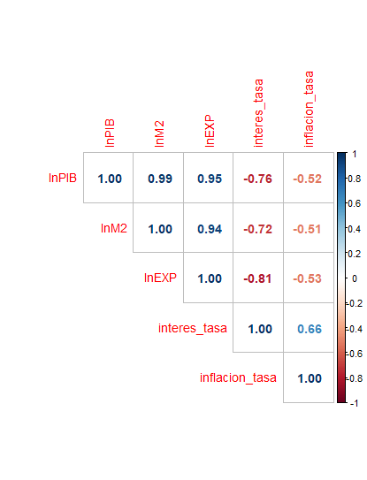

**Nota.** Elaboración propia.

```r
library(knitr)
library(kableExtra)

tabla2 <- data.frame(
  Variables = c("lnPIB", "lnM2", "lnEXP", "Interés", "Inflación"),
  lnPIB = c(1.000, 0.989, 0.947, -0.765, -0.521),
  lnM2 = c(0.989, 1.000, 0.940, -0.717, -0.514),
  lnEXP = c(0.947, 0.940, 1.000, -0.808, -0.527),
  Interés = c(-0.765, -0.717, -0.808, 1.000, 0.658),
  Inflación = c(-0.521, -0.514, -0.527, 0.658, 1.000)
)

kable(
  tabla2,
  caption = "Tabla 2. Matriz de correlación de Pearson",
  align = c("l", "c", "c", "c", "c", "c"),
  digits = 3,
  booktabs = TRUE
) %>%
  kable_styling(
    full_width = FALSE,
    position = "center"
  ) %>%
  footnote(
    general = "Elaboración propia mediante RStudio.",
    general_title = "Nota: "
  )
```

Tabla 2. Matriz de correlación de Pearson

| Variables | lnPIB | lnM2 | lnEXP | Interés | Inflación |
| --- | --- | --- | --- | --- | --- |
| lnPIB | 1.000 | 0.989 | 0.947 | -0.765 | -0.521 |
| lnM2 | 0.989 | 1.000 | 0.940 | -0.717 | -0.514 |
| lnEXP | 0.947 | 0.940 | 1.000 | -0.808 | -0.527 |
| Interés | -0.765 | -0.717 | -0.808 | 1.000 | 0.658 |
| Inflación | -0.521 | -0.514 | -0.527 | 0.658 | 1.000 |

Nota:  
Elaboración propia mediante RStudio.

Los resultados evidencian una relación positiva muy fuerte entre el PIB real y la liquidez monetaria (r= 0,989), así como entre el PIB real y las exportaciones (r=0,947), la tasa de interés presenta una relación inversa con el crecimiento económico (e=-0,765), mientras que la inflación muestra una correlación negativa de magnitud moderada (r= -0521). Estas asociaciones son consistentes con la teoría económica y justifican la inclusión de estas variables dentro del modelo ARDL.

**Figura 2**

*Matriz gráfica de dispersión.*

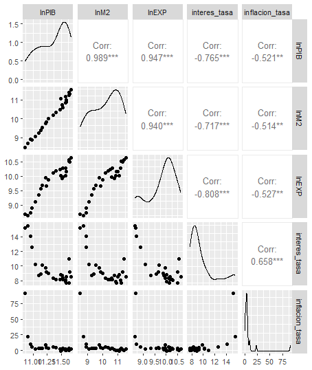

**Nota.** Elaboración propia en RStudio.

La matriz grafica de dispersión permite visualizar la relación bivariado entre todas las variables incluidas en el estudio. En la diagonal principal se presenta la distribución de cada variable, mientras que en el triangulo inferior se observan los diagramas de dispersión y en el superior los coeficientes de correlación de Pearson. La figura 2 confirma una asociación positiva entre el PIB real, la liquides monetaria y las exportaciones, así como una relación negativa entre el PIB real y la tasa de interés, resultados que respaldan el análisis estadístico previo y la especificación del modelo econométrico.

## **Resultados del análisis econométrico**

Debido a que las pruebas de normalidad, heteroscedasticidad, autocorrelación y estabilidad no se aplican a los datos originales, sino los residuos del modelo estimado.

### **Prueba de raíz unitaria (ADF)**

Antes de estimar el modelo RDL se evaluó el orden de integración de las variables mediante la prueba de Dickey-Fuller Aumentada (ADF). Esta prueba permite determinar si las series son estacionarias o presentan raíz unitaria, condición necesaria para verificar la aplicabilidad del modelo ARDL, el cual admite variables integradas de orden 1(0) y 1(1) pero no de orden 1(2).

En este estudio se utilizó la especificación con tendencia determinística y la selección automática de rezagos mediante el criterio de información de Akaike (AIC), La hipótesis nula establece la existencia de raíz unitaria (serie no estacionaria), mientas que la hipótesis alternativa sostiene que la serie es estacionaria.

```r
library(knitr)
library(kableExtra)

tabla_adf <- data.frame(
  Variable = c("lnPIB", "lnM2", "lnEXP", "Tasa de interés", "Inflación"),
  `Estadístico ADF` = c(-1.214, -0.733, -2.133, -3.601, -3.817),
  `Valor crítico (5%)` = c(-3.5, -3.5, -3.5, -3.5, -3.5),
  Decisión = c("No estacionaria", "No estacionaria", "No estacionaria",
               "Estacionaria", "Estacionaria")
)

kable(
  tabla_adf,
  caption = "Tabla 3. Resultados de la prueba de Dickey Fuller Aumentada (ADF)",
  align = c("l", "c", "c", "c"),
  digits = 3,
  booktabs = TRUE
) %>%
  kable_styling(
    full_width = FALSE,
    position = "center"
  ) %>%
  footnote(
    general = "Elaboración propia en RStudio.",
    general_title = "Nota: "
  )
```

Tabla 3. Resultados de la prueba de Dickey Fuller Aumentada (ADF)

| Variable | Estadístico.ADF | Valor.crítico..5.. | Decisión |
| --- | --- | --- | --- |
| lnPIB | -1.214 | -3.5 | No estacionaria |
| lnM2 | -0.733 | -3.5 | No estacionaria |
| lnEXP | -2.133 | -3.5 | No estacionaria |
| Tasa de interés | -3.601 | -3.5 | Estacionaria |
| Inflación | -3.817 | -3.5 | Estacionaria |

Nota:  
Elaboración propia en RStudio.

Los resultados muestran que lnPIB, lnM2 y lnEXP no son estacionarias en niveles, mientras que la tasa de interés y la inflación si resulta estacionaria al 5% de significancia. Esta combinación de variables 1(0) y 1(1) constituye un requisito para la aplicación del modelo ARDL, por lo que el siguiente apartado se verifica la estacionariedad de las variables no estacionarias mediante su primera diferencia.

### **Prueba de estacionariedad (KPSS)**

Con el objetivo de complementar y robustecer los resultados obtenidos en ADF se aplicó la prueba de KPSS (Kwiatkowski-Phillips-Schmidt-Shin), la cual permite evaluar la estacionariedad de las series desde un enfoque contrario al de la prueba de raíz unitaria.

```r
library(knitr)
library(kableExtra)

tabla_kpss <- data.frame(
  Variable = c("lnPIB", "lnM2", "lnEXP", "Tasa de interés", "Inflación"),
  `Estadístico KPSS` = c(0.92735, 0.95648, 0.82564, 0.55224, 0.44523),
  `p-valor` = c(0.01, 0.01, 0.01, 0.0299, 0.0577),
  Decisión = c("No estacionaria", "No estacionaria", "No estacionaria",
               "No estacionaria", "Estacionaria")
)

kable(
  tabla_kpss,
  caption = "Tabla 4. Resultados de la prueba KPSS",
  align = c("l", "c", "c", "c"),
  digits = 5,
  booktabs = TRUE
) %>%
  kable_styling(
    full_width = FALSE,
    position = "center"
  ) %>%
  footnote(
    general = "Elaboración propia con resultados obtenidos en RStudio.",
    general_title = "Nota: "
  )
```

Tabla 4. Resultados de la prueba KPSS

| Variable | Estadístico.KPSS | p.valor | Decisión |
| --- | --- | --- | --- |
| lnPIB | 0.92735 | 0.0100 | No estacionaria |
| lnM2 | 0.95648 | 0.0100 | No estacionaria |
| lnEXP | 0.82564 | 0.0100 | No estacionaria |
| Tasa de interés | 0.55224 | 0.0299 | No estacionaria |
| Inflación | 0.44523 | 0.0577 | Estacionaria |

Nota:  
Elaboración propia con resultados obtenidos en RStudio.

```r
library(knitr)
library(kableExtra)

tabla_adf_diff <- data.frame(
  Variable = c("ΔlnPIB", "ΔlnM2", "ΔlnEXP"),
  `Estadístico ADF` = c(-3.5123, -3.9458, -3.5568),
  `Valor crítico (5%)` = c(-3, -3, -3),
  Decisión = c("Estacionaria", "Estacionaria", "Estacionaria")
)

kable(
  tabla_adf_diff,
  caption = "Tabla 5. Resultados de la prueba ADF en primeras diferencias",
  align = c("l", "c", "c", "c"),
  digits = 4,
  booktabs = TRUE
) %>%
  kable_styling(
    full_width = FALSE,
    position = "center"
  ) %>%
  footnote(
    general = "Autoría propia con resultados obtenidos en RStudio.",
    general_title = "Nota: "
  )
```

Tabla 5. Resultados de la prueba ADF en primeras diferencias

| Variable | Estadístico.ADF | Valor.crítico..5.. | Decisión |
| --- | --- | --- | --- |
| ΔlnPIB | -3.5123 | -3 | Estacionaria |
| ΔlnM2 | -3.9458 | -3 | Estacionaria |
| ΔlnEXP | -3.5568 | -3 | Estacionaria |

Nota:  
Autoría propia con resultados obtenidos en RStudio.

Esto prueba en primeras diferencias que todas las variables analizadas presentan estadísticos t (tau) mas negativos que el valor critico al 5% de significación, por tanto, se rechaza la hipótesis nula de presencia de raíz unitaria, concluyendo que las series son estacionarias en primeras diferencias. Estas variables son integradas de orden 1(1); este resultado en conjunto con las variables que fueron estacionarias en niveles 1(0), confirma la existencia de una combinación de ordenes de integración.

### **Estimación del modelo ARDL**

El modelo incorpora tanto valores contemporáneos como rezagados de la variable dependiente y de las variables explicativas, lo que permite capturar la dinámica temporal de corto plazo entre las variables macroeconómicas analizadas.

```r
library(knitr)
library(kableExtra)

tabla_ardl <- data.frame(
  Variable = c(
    "L(lnPIB,1)", "L(lnPIB,2)",
    "lnM2", "L(lnM2,1)", "L(lnM2,2)",
    "lnEXP", "L(lnEXP,1)", "L(lnEXP,2)",
    "interes_tasa", "L(interes_tasa,1)", "L(interes_tasa,2)",
    "inflacion_tasa", "L(inflacion_tasa,1)", "L(inflacion_tasa,2)"
  ),
  Coeficiente = c(
    0.5705, 0.9232,
    -0.2418, 0.0718, -0.0223,
    0.3565, -0.143, -0.07,
    -0.0227, -0.0038, 0.0144,
    0.0001, 0.0139, -0.0005
  ),
  `Error estándar` = c(
    0.2164, 0.337,
    0.1686, 0.1301, 0.1292,
    0.0749, 0.0759, 0.0463,
    0.0087, 0.0127, 0.014,
    0.0043, 0.0053, 0.0013
  ),
  `t-valor` = c(
    2.636, 2.739,
    -1.434, 0.552, -0.173,
    4.754, -1.883, -1.513,
    -2.602, -0.3, 1.029,
    0.015, 2.632, -0.405
  ),
  Significancia = c(
    "**", "**",
    "n.s", "n.s", "n.s",
    "***", ".", "n.s",
    "**", "n.s", "n.s",
    "n.s", "**", "n.s"
  )
)

kable(
  tabla_ardl,
  caption = "Tabla 6. Resultados del modelo ARDL",
  align = c("l", "c", "c", "c", "c"),
  digits = 4,
  booktabs = TRUE
) %>%
  kable_styling(
    full_width = FALSE,
    position = "center"
  ) %>%
  footnote(
    general = "Autoría propia con resultados obtenidos en RStudio. R² = 0.9971; R² ajustado = 0.9926; F-estadístico = 220.3 (p < 0.01).",
    general_title = "Nota: "
  )
```

Tabla 6. Resultados del modelo ARDL

| Variable | Coeficiente | Error.estándar | t.valor | Significancia |
| --- | --- | --- | --- | --- |
| L(lnPIB,1) | 0.5705 | 0.2164 | 2.636 | ** |
| L(lnPIB,2) | 0.9232 | 0.3370 | 2.739 | ** |
| lnM2 | -0.2418 | 0.1686 | -1.434 | n.s |
| L(lnM2,1) | 0.0718 | 0.1301 | 0.552 | n.s |
| L(lnM2,2) | -0.0223 | 0.1292 | -0.173 | n.s |
| lnEXP | 0.3565 | 0.0749 | 4.754 | *** |
| L(lnEXP,1) | -0.1430 | 0.0759 | -1.883 | . |
| L(lnEXP,2) | -0.0700 | 0.0463 | -1.513 | n.s |
| interes_tasa | -0.0227 | 0.0087 | -2.602 | ** |
| L(interes_tasa,1) | -0.0038 | 0.0127 | -0.300 | n.s |
| L(interes_tasa,2) | 0.0144 | 0.0140 | 1.029 | n.s |
| inflacion_tasa | 0.0001 | 0.0043 | 0.015 | n.s |
| L(inflacion_tasa,1) | 0.0139 | 0.0053 | 2.632 | ** |
| L(inflacion_tasa,2) | -0.0005 | 0.0013 | -0.405 | n.s |

Nota:  
Autoría propia con resultados obtenidos en RStudio. R² = 0.9971; R² ajustado = 0.9926; F-estadístico = 220.3 (p < 0.01).

- LnM2 (T): Efecto contemporáneo.
- L(lnM2,1): efecto del periodo anterior (t-1)
- L(lnM2,2): efecto de hace dos periodos (t-2)

De esta manera podemos analizar los impactos inmediatos y también la evolución de dicho impacto, lo cual es clave para poder entender la relación en el corto y largo plazo del caso de estudió. Los resultados del modelo ARDL evidencian un alto nivel de ajuste global, con un R^2=0.9971 y un R^2 ajustado=0.9926, lo que indica que el modelo explica de manera significativa la variabilidad del PIB en función de las variables explicativas incluidas.

En términos dinámicos, se observa que el PIB presenta una fuerte persistencia temporal, ya que sus rezagos son estadísticamente significativos; esto es indicador de que le comportamiento actual del PIB depende en gran medida de su evolución en periodos anteriores, lo cual es consistente con la naturaleza dinámica de las variables macroeconómicas.

Las exportaciones muestran un efecto positivo y estadísticamente significativo en el periodo contemporáneo (lnEXP= 0.3565), lo que indica que un incremento en las exportaciones genera un aumento inmediato en el PIB. Sin embargo, este efecto no se mantiene constante en el tiempo, ya que el primer rezago presenta un efecto negativo marginalmente significativo (-0.1430), mientras que el segundo rezago no es significativo (-0.0700); esto nos sugiere que el impacto positivo inicial se va ajustando gradualmente y pierde fuerza en periodos posteriores.

En el caso de la tasa de interés, se observa un efecto significativo en el periodo contemporáneo (-0.0227), lo que es coherente con la teoría económica, ya que un aumento en la tasa de interés reduce la inversión y la actividad económica. Por si parte la inflación presenta significancia en su primer rezago, lo que indica que sus efectos sobre el PIB se transmiten de manera contra cíclica. La variable M2 no representa significancia estadística en ninguna de sus especificaciones, lo que indica que su efecto sobre el PIB no es concluyente dentro del periodo a analizado.

**Figura 3**

*Modelo ARDL: valores observados vs ajustados.*

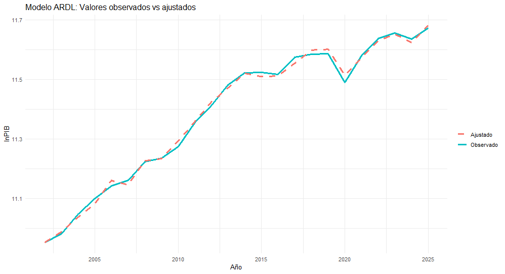

**Nota.** Autoría propia mediante RStudio.

Se puede evidenciar en la figura 3 la comparación entre los valores observados de la variable lnPIB y los valores ajust6ados por el modelo ARDL estimado; se observa una alta proximidad entre ambas series, lo que evidencia que el modelo logra replicar adecuadamente la dinámica del PIB a lo largo del periodo analizado. Esto es coherente con el alto coeficiente de determinación obtenido previamente.

### **Prueba de cointegración del modelo ARDL (Bounds test)**

Con el objetivo de determinar la existencia de una relación de equilibrio de largo plazo entre las variables del modelo, se aplico la prueba de cointegración mediante el enfoque de limites (bounds test). Esta prueba nos permitió contrastar la existencia de una relación de cointegración en el modelo ARDL evaluando si las variables mantienen una relacione estable en le largo plazo independiente de su orden de integración. La hipótesis nula establece la ausencia de cointegración entre las variables, mientas que la hipótesis alternativa plantea la existencia de una relación de largo plazo.

```r
library(knitr)
library(kableExtra)

tabla_bounds <- data.frame(
  "Estadístico F" = 5.9256,
  "p-valor" = 0.002319,
  "Decisión" = "Existe cointegración"
)

kable(
  tabla_bounds,
  caption = "Tabla 7. Resultados del Bound test",
  align = c("c", "c", "c"),
  digits = 6,
  booktabs = TRUE
) %>%
  kable_styling(
    full_width = FALSE,
    position = "center"
  ) %>%
  footnote(
    general = "Elaboración propia mediante resultados de prueba en RStudio.",
    general_title = "Nota: "
  )
```

Tabla 7. Resultados del Bound test

| Estadístico.F | p.valor | Decisión |
| --- | --- | --- |
| 5.9256 | 0.002319 | Existe cointegración |

Nota:  
Elaboración propia mediante resultados de prueba en RStudio.

Los resultados de la prueba muestran un estadístico de f= 5.9256 con un valor de p de 0.0023 19, el cual es estadísticamente significativo al 1% de nivel de significancia; por tanto, se rechaza la hipótesis nula de no cointegración.

### **Estimación de los coeficientes de largo plazo**

Una vez confirmada la existencia de cointegración mediante la prueba de bounds, se estimaron los coeficientes de largo plazo del modelo ARDL; estos representan la relación de equilibrio entre el PIB y las variables explicativas, permitiendo evaluar el efecto de cada una de ellas sobre la actividad económica.

Los coeficientes se obtuvieron a partir del modelo ARDL estimado, utilizando la función de multiplicadores de largo plazo, la cual transforma la especificación dinámica en una relación de equilibrio de largo plazo.

```r
library(knitr)
library(kableExtra)

tabla_largo_plazo <- data.frame(
  Variable = c("Constante", "lnM2", "lnEXP", "Tasa de interés", "Inflación"),
  Coeficiente = c(10.0209, 0.3896, -0.2906, 0.0246, -0.0273),
  `Error estándar` = c(0.8248, 0.1322, 0.2212, 0.0337, 0.0138),
  `t-valor` = c(12.1498, 2.9469, -1.3137, 0.7282, -1.9859),
  `p-valor` = c("<0.001", 0.0163, 0.2215, 0.485, 0.0783),
  Significancia = c("***", "**", "n.s.", "n.s.", "*")
)

kable(
  tabla_largo_plazo,
  caption = "Tabla 8. Resultados de los coeficientes de largo plazo del modelo ARDL",
  align = c("l", "c", "c", "c", "c", "c"),
  booktabs = TRUE
) %>%
  kable_styling(
    full_width = FALSE,
    position = "center"
  ) %>%
  footnote(
    general = "Elaboración propia, resultado de pruebas en RStudio.",
    general_title = "Nota: "
  )
```

Tabla 8. Resultados de los coeficientes de largo plazo del modelo ARDL

Variable

Coeficiente

Error.estándar

t.valor

p.valor

Significancia

Constante

10.0209

0.8248

12.1498

<0.001

***

lnM2

0.3896

0.1322

2.9469

0.0163

lnEXP

-0.2906

0.2212

-1.3137

0.2215

n.s.

Tasa de interés

0.0246

0.0337

0.7282

0.485

n.s.

Inflación

-0.0273

0.0138

-1.9859

0.0783

Nota:

Elaboración propia, resultado de pruebas en RStudio.

Los resultados evidencian que, en el largo plazo, la liquidez monetaria M2 presenta un efecto positivo y estadísticamente significativo sobre el PIB, el coeficiente estimado 0.3896 indica que, manteniendo constantes las demás variables un incremento del 1% en la liquidez monetaria se asocia con un aumento aproximado del 0,39% en el PIB en el largo plazo.

Por otro lado las exportaciones presentan un coeficiente negativo de -0.2906, aunque este no resulta estadísticamente significativo p= 02215, aunque las exportaciones constituyen un componente de identidad contable del PIB, este resultado indica quem una vez controlado el efecto de la liquidez monetaria, la tasa de interés y la inflación, no existe evidencia suficiente para afirmar que las exportaciones ejercen una influencia significativa para el crecimiento económico en el largo plazo durante el periodo analizad. Esto puede estar asociado a la estructura de las exportaciones ecuatorianas, las cuales están altamente concentradas en productos primarios y sujetas a la volatilidad de los mercados internacionales, así como la influencia de otros factores macroeconómicos que condicionan la dinámica del crecimiento, por ejemplo, la volatilidad de la balanza comercial.

En el tema de la tasa de interés, presenta un coeficiente de 0.0246, pero sin significancia estadística p= 0.4850 por lo que no se puede decir que ingluya de forma significativa en el crecimiento económico a largo plazo. La inflación registra un coeficiente negativo de -0.0273 y resulta significativo al 10% p= 0.0783; esto indica que mayores niveles de inflación tienden a reducir el PIB en el largo plazo, aunque la evidencia estadística es moderada y debe interpretarse con cautela.

### **Modelo de corrección de error (ECM): análisis del corto plazo**

Con el propósito de analizar la dinámica del corto plazo entre las variables, se estimó el Modelo de Corrección del Error, derivado del modelo ARDL previamente seleccionado; este nos permite evaluar el impacto inmediato de las variaciones de las variables sobre el crecimiento económico, así también como el proceso de ajuste de equilibrio en el largo plazo.

```r
library(knitr)
library(kableExtra)

tabla_ecm <- data.frame(
  Variable = c(
    "ΔlnPIB(-1)",
    "ΔlnM2",
    "ΔlnM2(-1)",
    "ΔlnEXP",
    "ΔlnEXP(-1)",
    "ΔTasa de interés",
    "ΔTasa de interés(-1)",
    "ΔInflación",
    "ΔInflación(-1)"
  ),
  Coeficiente = c(
    -0.9232,
    -0.2418,
    0.0223,
    0.3565,
    0.0701,
    -0.0227,
    -0.0144,
    0.0001,
    0.0005
  ),
  `Error estándar` = c(
    0.2004,
    0.0817,
    0.0733,
    0.0497,
    0.0343,
    0.0043,
    0.006,
    0.0025,
    0.0006
  ),
  `t-valor` = c(
    -4.608,
    -2.961,
    0.305,
    7.168,
    2.043,
    -5.259,
    -2.404,
    0.026,
    0.869
  ),
  `p-valor` = c(
    0.0005,
    0.011,
    0.7655,
    "<0.001",
    0.0619,
    "<0.001",
    0.0319,
    0.9795,
    0.4006
  ),
  Significancia = c(
    "***",
    "**",
    "n.s.",
    "***",
    "*",
    "***",
    "**",
    "n.s.",
    "n.s."
  )
)

kable(
  tabla_ecm,
  caption = "Tabla 9. Resultados del ECM derivado del modelo ARDL",
  align = c("l", "c", "c", "c", "c", "c"),
  booktabs = TRUE
) %>%
  kable_styling(
    full_width = FALSE,
    position = "center"
  ) %>%
  footnote(
    general = "Elaboración propia, resultados obtenidos en RStudio.",
    general_title = "Nota: "
  )
```

Tabla 9. Resultados del ECM derivado del modelo ARDL

Variable

Coeficiente

Error.estándar

t.valor

p.valor

Significancia

ΔlnPIB(-1)

-0.9232

0.2004

-4.608

5e-04

***

ΔlnM2

-0.2418

0.0817

-2.961

0.011

ΔlnM2(-1)

0.0223

0.0733

0.305

0.7655

n.s.

ΔlnEXP

0.3565

0.0497

7.168

<0.001

***

ΔlnEXP(-1)

0.0701

0.0343

2.043

0.0619

ΔTasa de interés

-0.0227

0.0043

-5.259

<0.001

***

ΔTasa de interés(-1)

-0.0144

0.0060

-2.404

0.0319

ΔInflación

0.0001

0.0025

0.026

0.9795

n.s.

ΔInflación(-1)

0.0005

0.0006

0.869

0.4006

n.s.

Nota:

Elaboración propia, resultados obtenidos en RStudio.

### **Pruebas de normalidad y de diagnostico**

La prueba de Shapiro-Wilk se aplicó para comprobar si los residuos del modelo se aproximan a una distribución normal. Esta prueba compara los cuantiles observados de la muestra con los cuantiles esperados de una distribución normal teórica. Además, presenta una elevada capacidad para detectar desviaciones de la normalidad en muestras pequeñas y medianas, por lo que resulta apropiada para investigaciones con un número reducido de observaciones (Panchi & Panchi, 2025)

La prueba de Jarque-Bera se utilizó para evaluar la normalidad de los residuos mediante el análisis conjunto de su asimetría y curtosis. Un valor elevado del estadístico Jarque-Bera indica que estas características se alejan de las correspondientes a una distribución normal. Esta prueba es particularmente utilizada en el análisis de residuos de modelos de regresión, aunque puede presentar menor potencia estadística en muestras pequeñas (Panchi & Panchi, 2025) Para verificar que la varianza de los residuos del modelo ARDL se mantuviera constante durante el periodo analizado, se aplicó la prueba de Breusch–Pagan. La hipótesis nula establece la existencia de homocedasticidad, mientras que la hipótesis alternativa plantea que la varianza de los errores no es constante. El cumplimiento de este supuesto es importante para garantizar que los errores estándar, los p-valores y las pruebas de significancia de los coeficientes sean confiables (Alonso, 2024).

La prueba CUSUM se aplicó para evaluar la estabilidad de los parámetros del modelo durante el periodo analizado. Este procedimiento se basa en la suma acumulada de los residuos recursivos estandarizados y permite identificar desviaciones sistemáticas que podrían reflejar cambios estructurales. Cuando la trayectoria del estadístico se mantiene dentro de las bandas críticas de confianza, se considera que no existe evidencia de inestabilidad en los parámetros; en cambio, si supera dichos límites, se presume la presencia de un posible quiebre estructural (Gachet et al., 2011). La prueba de límites o Bounds Test se empleó para determinar si existe una relación de equilibrio de largo plazo entre el PIB real, la liquidez total M2, la tasa de interés, la inflación y las exportaciones. Este procedimiento, aplicado dentro de la metodología ARDL, contrasta la significancia conjunta de las variables rezagadas en niveles. Cuando el estadístico calculado supera el valor crítico del límite superior, se rechaza la hipótesis de ausencia de cointegración y se concluye que las variables mantienen una relación estable de largo plazo (Cueva-Rodríguez & Jácome-Estrella, 2024)

La prueba de Breusch-Pagan se aplicó para comprobar si la varianza de los residuos del modelo permanece constante. Este contraste permite detectar la presencia de heterocedasticidad, es decir, determinar si la dispersión del término de error cambia sistemáticamente en función de las variables explicativas. La verificación de este supuesto es importante porque la heterocedasticidad puede afectar la eficiencia de los estimadores y la confiabilidad de los errores estándar utilizados para realizar inferencias estadísticas (Porter & Gujarati, 2010).

```r
library(knitr)
library(kableExtra)

tabla_diag <- data.frame(
  Prueba = c(
    "Shapiro-Wilk",
    "Jarque-Bera",
    "Breusch-Godfrey",
    "Breusch-Pagan",
    "RESET de Ramsey",
    "CUSUM",
    "VIF (máximo)"
  ),
  Estadístico = c(
    "W = 0.9633",
    "χ² = 1.2882",
    "LM = 1.1404",
    "BP = 17.9180",
    "F = 0.1249",
    "S = 0.3380",
    "12.8892"
  ),
  `p-valor` = c(
    "0.5079",
    "0.5251",
    "0.5654",
    "0.2105",
    "0.7329",
    "0.9355",
    "-"
  ),
  Resultado = c(
    "Normalidad",
    "Normalidad",
    "Sin autocorrelación",
    "Homocedasticidad",
    "Modelo bien especificado",
    "Parámetros estables",
    "Multicolinealidad moderada"
  )
)

kable(
  tabla_diag,
  caption = "Tabla 10. Resultados de las pruebas de normalidad y diagnóstico del modelo ARDL",
  align = c("l", "c", "c", "c"),
  booktabs = TRUE
) %>%
  kable_styling(
    full_width = FALSE,
    position = "center"
  ) %>%
  footnote(
    general = "Autoría propia con resultados obtenidos en RStudio.",
    general_title = "Nota: "
  )
```

Tabla 10. Resultados de las pruebas de normalidad y diagnóstico del modelo ARDL

Prueba

Estadístico

p.valor

Resultado

Shapiro-Wilk

W = 0.9633

0.5079

Normalidad

Jarque-Bera

χ² = 1.2882

0.5251

Normalidad

Breusch-Godfrey

LM = 1.1404

0.5654

Sin autocorrelación

Breusch-Pagan

BP = 17.9180

0.2105

Homocedasticidad

RESET de Ramsey

F = 0.1249

0.7329

Modelo bien especificado

CUSUM

S = 0.3380

0.9355

Parámetros estables

VIF (máximo)

12.8892

Multicolinealidad moderada

Nota:

Autoría propia con resultados obtenidos en RStudio.

Los resultados de las pruebas de diagnostico evidencian que le modelo ARDL cumple satisfactoriamente con los principales supuestos econométricos. Las pruebas de Shapiro-Wilk p= 0.5079 y Jarque-Bera p=0.5251 indican que los residuos presentan una distribución normal aproximadamente normal. Así mismo la prueba de Breusch-Godfrey p=0.5654 no evidencian autor relación serial, mientras que la prueba de Breusch-Pagan p=0.2105 confirma la ausencia de heteroscedasticidad.

Por su parte la prueba de Reset de Ramsey p=0.7329 sugiere que la especificación funcional del modelo es adecuada y no existen errores de omisión relevantes. La prueba de Cusum p= 0.9355 confirma la estabilidad de los parámetros a lo largo del periodo analizado, al no encontrarse evidencia de cambios estructurales. El análisis de Factor de Inflación de la Varianza muestra que las variables presentan niveles de multicolinealidad aceptables para la estimación del modelo, aunque lnEXP registra el valor más elevado de 12.89, situación que era esperada dada la estrecha relación entre las variables macroeconómicas incluidas.

# **Conclusiones**

## **Conclusiones y discusión**

Los resultados obtenidos mediante la estimación del modelo ARDL-ECM permiten evidenciar la existencia de una relación dinámica entre la liquidez monetaria M2, la tasa de interés, las exportaciones, la inflación y el crecimiento económico del Ecuador en el periodo analizado; los hallazgos confirman la existencia de cointegración entre las variables, lo que sugiere que , a pesar de las fluctuaciones de corto plazo, existe un equilibrio estable de largo plazo entre los determinantes macroeconómicos y el PIB real.

El análisis de largo plazo, la liquidez monetaria M2 se consolida como la variable más relevante y consistente dentro del modelo, presentando un efecto positivo y estadísticamente significativo sobre el PIB; este resultado es coherente con la teoría monetaria y con la literatura empírica revisada, en la medida en que una mayor disponibilidad de liquide en el sistema financiero favorece la intermediación crediticia, estimula la inversión productiva y por ende impulsa el crecimiento económico. En el caso de una economía dolarizada como la ecuatoriana, este resultado adquiere mayor relevancia, ya que la expansión de la actividad económica depende en gran medida del comportamiento del sistema financiero interno y del ingreso de divisas externas.

Por otro lado, las exportaciones no muestran un efecto estadístico significativo en el largo plazo, lo cual puede explicarse por la estructura productiva del Ecuador, caracterizada por una alta dependencia de bienes primario y una limitada diversificación exportadores; esta condicione reduce la capacidad de las exportaciones para generar efectos sostenibles sobre el crecimiento económico, especialmente cuando están sujetas a la volatilidad de los precios internacionales. En cuanto a la tasa de interés, los resultados indican que su efecto de largo plazo no es significativo, lo que sugiere que su influencia se concreta principalmente en el corto plazo. Este comportamiento es consistente con la naturaleza del sistema financiero dolarizado, donde la tasa de interés no constituye un instrumento de política monetaria directa, sino un reflejo de las condiciones de liquidez y riesgo del sistema bancario.

Respecto a la inflación, se evidencia un efecto negativo débil pero consistente en el largo plazo. Este resultado es compatible con la teoría económica, ya que niveles persistentes de inflación tienden a erosionar el poder adquisitivo, generar incertidumbre y reducir la eficiencia en las decisiones de consumo e inversión, afectando de manera gradual el crecimiento económico. En el corto plazo, el modelo ECM muestra dinámicas diferenciadas; las exportaciones y la tasad e interés presentan efectos significativos sobre el crecimiento económico, lo que evidencia que estas variables operan principalmente como mecanismos de ajuste transitorio. En particular, el incremento de las exportaciones impulsa inmediatamente la actividad económica, mientras que aumenta la tasa de interés reducen el dinamismo del PIB debido al encarecimiento del crédito y la reducción de la inversión privada.

## **Conclusiones**

Los resultados de la investigación permiten concluir que la liquidez monetaria M2 constituye el principal determinante del crecimiento económico en el Ecuador dentro del periodo analizado, especialmente en el largo plazo. Efecto positivo y significativo confirma que, en una economía dolarizada, la expansión de la actividad económicas depende en gran medida de la disponibilidad de liquidez en la liquidez en el sistema financiero, lo cual condiciona el acceso al crédito, la inversión y el consumo.

Entonces podemos decir que la economía ecuatoriana presenta una fuerte dependencia de mecanismo financieros internos y externos, donde la política monetaria tradicional no tiene un rol activo. En este contexto, la tasa de interés actúa principalmente como un canal de transmisión de corto plazo, afectando el nivel de actividad económica a través del costo del financiamiento, pero sin generar efectos estructu8rales permanentes en el crecimiento. Por otra parte, las exportaciones no evidencian un impacto significativo en el largo plazo, lo que sugiere limitaciones estructurales del sector externo para impulsar de manera sostenida el crecimiento económico. Este resultado refleja la vulnerabilidad de la economía frente a la concentración en bienes primarios y la dependencia de los precios internacionales.

En la inflación, se evidencia que esta variable tiene un efecto negativo moderado en el largo plazo, lo que implica que su control sigue siendo relevante para la estabilidad macroeconómica, aunque su impacto sobre el crecimiento no es tan fuerte como el de la liquidez monetaria. El modelo ARDL-ECM es adecuado para analizar la dinámica del crecimiento económico en el Ecuador, ya que permite distinguir entre efectos de corto y largo plazo, así como identificar la existencia de un equilibrio estable entre las variables analizadas. Los resultados encontrados aportan evidencia empírica relevante para la formulación de políticas económicas orientadas a fortalecer la intermediación financiera y mejorar la capacidad de transmisión de la liquidez hacia el sector real de la economía.

# **Bibliografía**

Abdulkadr, A. A., Asnakew, Y. W., Sendkie, F. B., Workineh, E. B., & Asfaw, D. M. (2024). Analyzing the dynamics of monetary policy and economic growth in Ethiopia: An autoregressive distributed lag (ARDL) approach. *Discover Sustainability, 5*(1), 90. https://doi.org/10.1007/s43621-024-00271-w

Aceves Mejía, M., Absalón Copete, C., Aceves Mejía, M., & Absalón Copete, C. (2023). Inflación y Crecimiento Económico en América Latina, una relación no lineal. *Investigación Económica, 82*(326), 185–211. https://doi.org/10.22201/fe.01851667p.2023.326.86215

Banco Central del Ecuador. (2016, septiembre 1). La economía ecuatoriana creció en 0.2% en el 2015. https://www.bce.fin.ec/la-economia-ecuatoriana-crecio-en-02-en-el-2015/

Banco Central del Ecuador. (2022). Un acercamiento al mundo de las tasas de interés. https://www.bce.fin.ec/economiatricolor/educacion-financiera-y-monetaria/articulos/un-acercamiento-al-mundo-de-las-tasas-de-interes/

Banco Central del Ecuador. (2025). ABC del BCE - Tasa de interés activa. https://www.bce.fin.ec/economiatricolor/inclusion-financiera/abc-del-bce/abc-del-bce-tasa-de-interes-activa/

Bui, T. T., & Gábor, K. D. (2021). Measuring monetary policy by money supply and interest rate: Evidence from emerging economies. *Review of Economic Perspectives, 21*(3), 347–367. https://doi.org/10.2478/revecp-2021-0015

Checo, A., Grigoli, F., & Sandri, D. (2024). Transmisión de la política monetaria en los mercados emergentes. *FMI Working Papers, 2024*(093). https://doi.org/10.5089/9798400268564.001

Cuadrado-Roura, J., Mancha-Navarro, T., Villena, J., Casares, J., González, M., & Peinado, M. (2010). *Política económica: Elaboración, objetivos e instrumentos*.

Galí, J. (2021). Monetary policy and bubbles in a New Keynesian model. *American Economic Journal: Macroeconomics, 13*(2), 121–167. https://doi.org/10.1257/mac.20180427

Intriago, C. E. O. (2022). ¿Cómo incide la inflación económica sobre el ahorro? Algunas propuestas para la sostenibilidad familiar. *E-IDEA Journal of Business Sciences, 4*(15), 8–19. https://doi.org/10.53734/eidea.vol4.id196

Ioannou, S., & Wójcik, D. (2022). Was Adam Smith an economic geographer? *GeoJournal, 87*(6), 5425–5434. https://doi.org/10.1007/s10708-021-10499-y

León, M., & González, M. de la O. B. (2022). Monetary policy effects in dollarized economies. *Revista de Economía Mundial, (61)*, 137–157. https://doi.org/10.33776/rem.v0i61.5268

Mankiw, N. G. (2012). *Principles of economics* (6th ed.). South-Western Cengage Learning.

Meireles, M., & Rivera, G. (2023). Dolarización, banca privada y rentabilidad financiera en Ecuador. *Problemas del Desarrollo, 54*(215), 149–172. https://doi.org/10.22201/iiec.20078951e.2023.215.70021

Paredes, G., & Freire, V. S. (2024). Ecuador: El camino al sobreendeudamiento en un país sin moneda propia, 2010-2024. *Ciclos en la Historia, la Economía y la Sociedad*, (63), 23–62. https://doi.org/10.56503/3z5k0f03

Paredes, G. J., & Donoso, M. R. (2022). El patrón exportador del Ecuador en dolarización: ¿Nuevos hallazgos? *Revista Economía, 74*(120), 41–61. https://doi.org/10.29166/economa.v74i120.4177

Pérez, D., & Guncay, C. (2019). Endogeneidad de la oferta monetaria en Ecuador. *Cuestiones Económicas, 29*(1). https://doi.org/10.47550/RCE/29.1.4

Ponce, E. A. P., Rendón, L. A. V., Zambrano, D. S. C., Guevara, R. M. L., & Rizo, F. S. C. (2025). El impacto de las exportaciones en el crecimiento económico de Ecuador (2000–2023). *LATAM Revista Latinoamericana de Ciencias Sociales y Humanidades, 6*(2), 35–46. https://doi.org/10.56712/latam.v6i2.3603

Pulgar, W. C., Rodríguez, E., Basantes, K. Á., & Díaz, L. S. (2024). Exportaciones, inversión y gasto público como impulsores del PIB en Ecuador. *Revista Ñeque, 7*(18), 180–190. https://doi.org/10.33996/revistaneque.v7i18.134

Reyes, R. D. O., Flores, J. L. R., & Rosado, J. R. D. (2024). Evolución del PIB y factores de crecimiento en Ecuador (2018–2021). *X-pedientes Económicos, 8*(19). https://ojs.supercias.gob.ec/index.php/X-pedientes_Economicos/article/view/176

Sultana, N. (2018). Impacts of money supply, inflation rate and interest rate on economic growth: A case of Bangladesh. http://doi.one/10.1729/Journal.18824

Sumner, S. (2022). Whither monetarism? *Economic Affairs, 42*(2), 275–287. https://doi.org/10.1111/ecaf.12531

Vargas, L. L. C. E., & Muñoa, M. A. M. (2020). Estudio sobre la tasa de interés de referencia de Estados Unidos y su comportamiento en la inversión peruana. *INNOVA Research Journal, 5*(3.1), 244–262. https://doi.org/10.33890/innova.v5.n3.1.2020.1510

Zuluaga, J. S. G., & Checa, A. G. B. (2023). Oferta y demanda monetaria en Ecuador desde el año 2011–2021. *Ciencia Latina, 7*(4), 5007–5018. https://doi.org/10.37811/cl_rcm.v7i4.7326

Alonso, J. C. (2024). *Introducción al modelo clásico de regresión para científicos de datos en R*. Universidad Icesi. https://doi.org/10.18046/EUI/bda.h.4

Banco Central del Ecuador. (2016, septiembre 1). La economía ecuatoriana creció en 0.2% en el 2015. https://www.bce.fin.ec/la-economia-ecuatoriana-crecio-en-02-en-el-2015/

Cueva-Rodríguez, L., & Jácome-Estrella, H. de J. (2024). Productividad laboral del sector de servicios y crecimiento económico en Ecuador. *Problemas del Desarrollo, 55*(216), 113–139.

Gachet, I., Maldonado, D., Oliva, N., & Ramírez-Álvarez, J. (2011). *Hechos estilizados de la economía ecuatoriana: El ciclo económico 1965–2008*.

Panchi, P. A. M., & Panchi, D. F. M. (2025). Pruebas estadísticas de normalidad: Un análisis comparativo entre Kolmogórov-Smirnov, Shapiro-Wilk, Anderson-Darling, Ryan-Joiner y Jarque-Bera. *CIENCIA UNEMI, 18*(49). https://doi.org/10.29076/issn.2528-7737vol18iss49.2025pp%25pp

Porter, D. C., & Gujarati, D. N. (2010). *Econometría*. McGraw-Hill. https://bibliotecadigital.uce.edu.ec/s/L-D/item/619#?c=&m=&s=&cv=